# Fall 2021 - Math 421 - Midterm

## III. Predictive Models

Continue with the data from part I. Use the follows as the target and input variables:

*Target Variable*: Create the target variable taking value of

- `low` if the total charge of a patient (`tot`) is smaller than the median of the total charge, and
- `high` otherwise.

```r
median(df1$tot)
```

```
## [1] 21854
```

```r
df1$target <- ifelse(df1$tot < median(df1$tot), "low", "high")

head(df1)
```

```
## # A tibble: 6 x 43
##     yod pay_ub92   age   sex raceethn provider   moa   yoa   mod admtype asource
##   <dbl>    <dbl> <dbl> <dbl> <chr>    <fct>    <dbl> <dbl> <dbl>   <dbl> <chr>
## 1    18        9     0     1 1        7214         1    18     1       4 S
## 2    18        2    76     2 1        7214         1    18     1       3 1
## 3    18        6    50     2 1        7214        12    17     1       2 1
## 4    18        4     0     1 7        7214         1    18     1       4 S
## 5    18       13     0     1 1        7214        12    17     1       4 S
## 6    18        4     0     2 9        7214        12    17     1       4 T
## # ... with 32 more variables: los <dbl>, service <chr>, icu <chr>, ccu <chr>,
## #   dispub92 <chr>, payer <chr>, drg <dbl>, trandb <chr>, randbg <chr>,
## #   randbs <chr>, orr <chr>, anes <chr>, seq <chr>, lab <chr>, dtest <chr>,
## #   ther <chr>, blood <chr>, phar <chr>, other <chr>, patcon <chr>,
## #   total <chr>, tot <dbl>, b_wt <chr>, ancilar <chr>, campus <dbl>,
## #   er_fee <chr>, er_chrg <chr>, obs_chrg <chr>, psycchrg <chr>, race <chr>,
## #   ins_payer <chr>, target <chr>
```

*Input Variables*:

- “age”,“sex”,“raceethn”,“provider”,“moa”,“mod”,“admtype”,“campus”, ‘los’

```r
model_df <- df1 %>% select("target", "age", "sex","provider", "moa","mod","raceethn", "admtype", "campus", "los" )
names(df1)[1] <- 'target'

names(model_df)
```

```
##  [1] "target"   "age"      "sex"      "provider" "moa"      "mod"
##  [7] "raceethn" "admtype"  "campus"   "los"
```

```r
model_df <- drop_na(model_df, age, sex, raceethn, moa, mod, campus, los, target)
```

```r
model_df <- model_df %>% filter(admtype==1|admtype==2)
model_df$sex = factor(model_df$sex)
model_df$raceethn = factor(model_df$raceethn)
model_df$provider = factor(model_df$provider)
model_df$campus = factor(model_df$campus)
model_df$admtype=factor(model_df$admtype)
model_df$target=factor(model_df$target)
```

```r
library(caret)
set.seed(2020)
splitIndex <- createDataPartition(model_df$target, p=.05, list=FALSE)
model_df_train <- model_df[splitIndex,]
model_df_test <- model_df[-splitIndex,]
```

```r
library(rpart)

dec_tree <- rpart(target ~ ., data = model_df_train,
                 control = rpart.control(maxdepth = 5))

dec_tree$variable.importance
```

```
##        los   provider        age     campus    admtype        mod   raceethn
## 842.956278 188.275510  59.610091  53.832234  11.148687   3.822407   2.640591
```

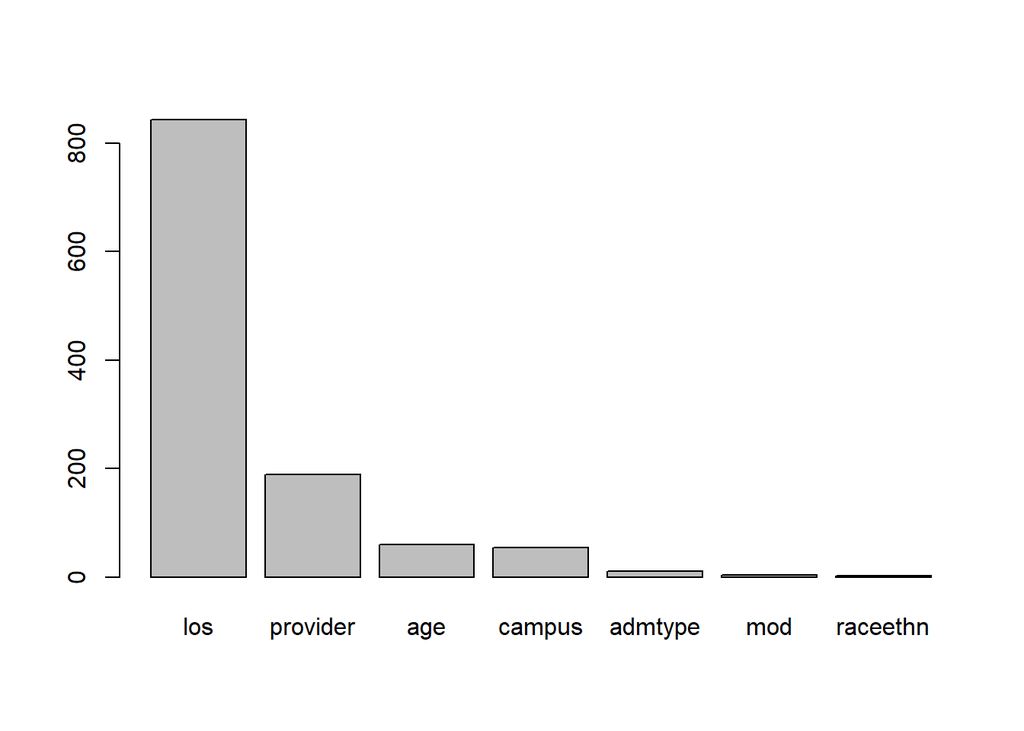

```r
barplot(dec_tree$variable.importance)
```

3. Using caret for this question. Set `Training Control` to be: Use Cross-Validation of 5 folds across all models. Train & tune at least 3 different models (i.e. three different values for `method=` in the train function of caret). Plot the hyper-parameter tuning plots for each model.

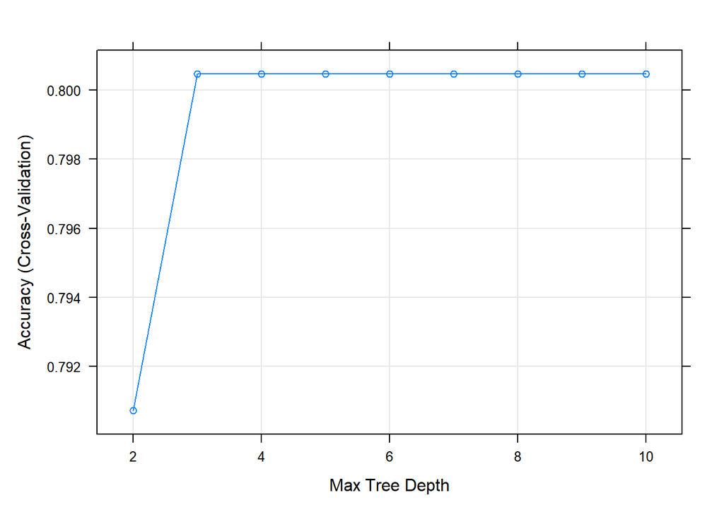

```r
#Decision Tree Model

tuneGrid = expand.grid(maxdepth = 2:10)
trControl = trainControl(method = "cv",
                         number = 5)
tree_approach <- train(target~., data=model_df_train,
                                method = "rpart2",
                                trControl = trControl,
                                tuneGrid = tuneGrid)
plot(tree_approach)
```